# homework2

zhuzhengda

2015年11月24日

# Hierarchical clustering using original data

Here I invoke built-in function to perform the HC. According to the heatmap, we can easily figure out that the patients should be divided into two types. And we can see how it work out using the indicator of ‘ER_Status_nature2012’ as the control group. I use the first two variables to define the coordinates of each patient in the map of the results. The corlor of each point represents our clustering results and the shape represents the respective referential index.

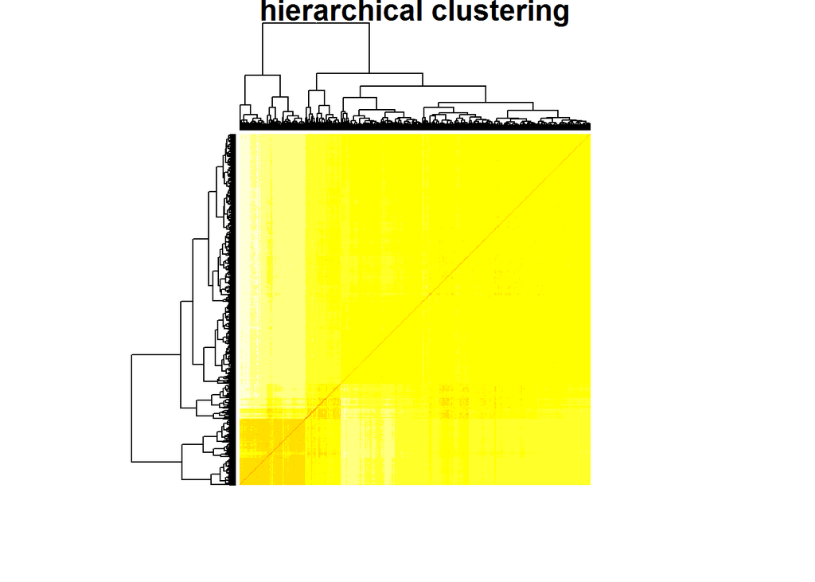

```
## [1] "Recognized samples:"
## [1] 440
## [1] "mis-classification:"
## [1] 38
## [1] "err classification rate:"
## [1] 0.08636364
```

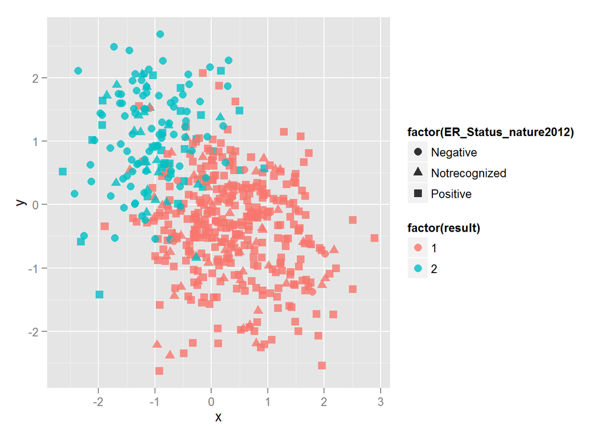

```r
patient<-read.table("GeneMatrix.txt",sep ='\t',header=TRUE,as.is=TRUE) # read in the data
patient<-t(patient)

HC<-function(patient){
  dist.e<-dist(patient,method='euclidean')  # hierarchical clustering using euclidean
  heatmap(as.matrix(dist.e),labRow = F, labCol = F,main = 'hierarchical clustering') #Cluster map
  model1<-hclust(dist.e)
  result<-cutree(model1,k=2) # classification according to 'k'
  info<-read.table("clinical_data",sep ='\t',header=TRUE,as.is=TRUE) # read in somemore information to find the criteria to analysis the result
  m<-length(result)
  cr<-rep("positive",m)
  recog<-0
  err<-0
  for(i in 1:m){
    str<-attr(result,"name")[i]
    s<-unlist(strsplit(str, "\\."))
    cg<-paste(s[1],s[2],s[3],s[4],sep="-")
    #temp<-subset(info,sampleID==attr(result,"name")[i])
    temp<-subset(info,sampleID==cg)
    if(dim(temp)[1]==0)
      cr[i]<-"Notrecognized" # if the patient do not have the corresponding information, a label of 'Notrecognized' will be defined
    else{
      cr[i]<-temp$ER_Status_nature2012
      recog<-recog+1
      if((cr[i]=="Positive"&&result[i]==2)||(cr[i]=="Negative"&&result[i]==1))
        err<-err+1
    }
  }
  x<-patient[,1]  # Here I use the first two variables to show the result
  y<-patient[,2]
  ER_Status_nature2012<-cr
  print("Recognized samples:")
  print(recog)
  print("mis-classification:")
  print(err)
  print("err classification rate:")
  print(err/recog)
  library(ggplot2)
  p<-ggplot(data.frame(x,y,ER_Status_nature2012,result),aes(x,y))
  p+geom_point(size=3,alpha=0.8,aes(colour=factor(result),shape = factor(ER_Status_nature2012)))
}
HC(patient)
```

# Hierarchical clustering using data processed by PCA

I realize the PCA algorithm and compress the initial data according to ‘rerr’(here ‘rerr’ equals 0.1) which means how much information will be thrown away after PCA. The compressed data shows there are 102 principal components extracted.

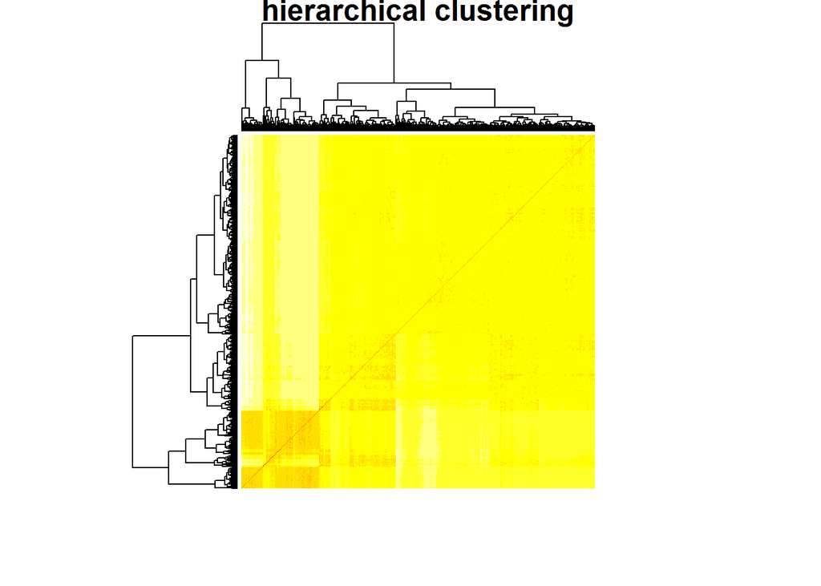

```
## [1] "Recognized samples:"
## [1] 440
## [1] "mis-classification:"
## [1] 28
## [1] "err classification rate:"
## [1] 0.06363636
```

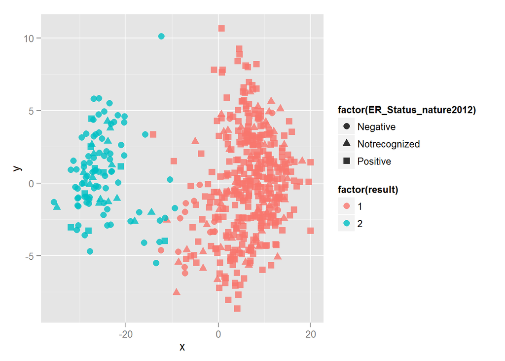

```r
PCA<-function(data,rerr){
  sd=scale(data)  # normalization
  c=cor(sd)
  e=eigen(c)
  v=e$value    # eigenvalues
  su=sum(v)
  m=dim(data)[1]
  n=dim(data)[2]
  num=0
  for(i in 1:m){  # find suitable number of eigenvalues and eigenvectors according to 'rerr'
    num=num+v[i]
    if((num/su)>(1-rerr))
      break
  }
  pcs=e$vectors[,1:i]
  cprs_data=data%*%pcs  # compressed data
  return(cprs_data)
}

patient<-read.table("GeneMatrix.txt",sep ='\t',header=TRUE,as.is=TRUE) # read in the data
patient<-t(patient)
cprs<-PCA(patient,0.1) # compressed data
HC(cprs)
```

# discussion

In the final of this procedure I count all the mis_classificated samples. And we can see the error classification rate decreases(from 0.086 to 0.064) if we compress the data using PCA, which proves the correctness of the classification in turn.